# Questions Based

1.Pease refer the table below to answer below questions: Planned to purchase Product A Actually placed and order for Product A - Yes Actually placed and order for Product A - No Total Yes 400 100 500 No 200 1300 1500 Total 600 1400 2000 1.Refer to the above table and find the joint probability of the people who planned to purchase and actually placed an order. 2.Refer to the above table and find the joint probability of the people who planned to purchase and actually placed an order, given that people planned to purchase.

# Answer:

1. Joint probability of the people who planned to purchase and actually placed an order = number of people who planned to purchase and actually placed an order/total number of people = 400/2000 = 0.2

2. Joint probability of the people who planned to purchase and actually placed an order, given that people planned to purchase = number of people who planned to purchase and actually placed an order/number of people who planned to purchase = 400/500 = 0.8

</hr

1. Question: An electrical manufacturing company conducts quality checks at specified periods on the products it manufactures. Historically, the failure rate for the manufactured item is 5%. Suppose a random sample of 10 manufactured items is selected. Answer the following questions. A. Probability that none of the items are defective? B. Probability that exactly one of the items is defective? C. Probability that two or fewer of the items are defective? D. Probability that three or more of the items are defective ?

```python
#Answer
import numpy as np
import scipy.stats as stats
p = 0.05
n = 10
k = np.arange(0,3)
binom = stats.binom.pmf(k,n,p) #calculating probability using binomial distribution
print('A. Probability that none of the items are defective=', binom[0], sep='')
print('B. Probability that exactly one of the items is defective=', binom[1], sep='')
print('C. Probability that two or fewer of the items are defective=', (binom[0]+binom[1]+binom[2]), sep='')
print('D. Probability that three or more of the items are defective=',(1-(binom[0]+binom[1]+binom[2])), sep='')
```

```
A. Probability that none of the items are defective=0.5987369392383789
B. Probability that exactly one of the items is defective=0.31512470486230504
C. Probability that two or fewer of the items are defective=0.9884964426207035
D. Probability that three or more of the items are defective=0.011503557379296536
```

</hr

1. Question: A car salesman sells on an average 3 cars per week. A. Probability that in a given week he will sell some cars. B. Probability that in a given week he will sell 2 or more but less than 5 cars. C. Plot the poisson distribution function for cumulative probability of cars sold per-week vs number of cars sold perweek.

```
A. Probability that in a given week he will sell some cars=0.950212931632136
B. Probability that in a given week he will sell 2 or more but less than 5 cars=0.6161149710523164
```

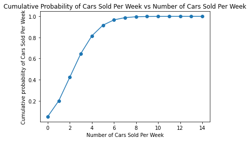

```python
#Answer
import matplotlib.pyplot as plt
rate = 3
a1 = np.arange(0,15)
psn = stats.poisson.pmf(a1,rate) #calculating probability using poisson distribution
print('A. Probability that in a given week he will sell some cars=', (1-psn[0]), sep='')
print('B. Probability that in a given week he will sell 2 or more but less than 5 cars=', (psn[2]+psn[3]+psn[4]), sep='')
psnc = np.cumsum(psn) #cumulative probability of cars sold per week
plt.plot(a1, psnc, '-o') #Plotting number of cars sold per week vs cumulative probability of cars sold per week
plt.title('Cumulative Probability of Cars Sold Per Week vs Number of Cars Sold Per Week')
plt.xlabel('Number of Cars Sold Per Week')
plt.ylabel('Cumulative probability of Cars Sold Per Week')
plt.show()
```

</hr

1. Question: Accuracy in understanding orders for a speech based bot at a restaurant is important for the Company X which has designed, marketed and launched the product for a contactless delivery due to the COVID-19 pandemic. Recognition accuracy that measures the percentage of orders that are taken correctly is 86.8%. Suppose that you place order with the bot and two friends of yours independently place orders with the same bot. Answer the following questions. A.What is the probability that all three orders will be recognised correctly? B.What is the probability that none of the three orders will be recognised correctly? C.What is the probability that at least two of the three orders will be recognised correctly?

```python
#Answer
p = 86.8/100
n = 3
k = np.arange(0,4)
binoml = stats.binom.pmf(k,n,p) #Calculating probability using Binomial Distribution as the actual probability is given and the total number of trials (3 orders in this case) is given.
print('A. Probability that all three orders will be recognised correctly=', binoml[3], sep='')
print('B. Probability that none of the three orders will be recognised correctly=', binoml[0], sep='')
print('C. Probability that at least two of the three orders will be recognised correctly=', binoml[2]+binoml[3], sep='')
```

```
A. Probability that all three orders will be recognised correctly=0.653972032
B. Probability that none of the three orders will be recognised correctly=0.002299968
C. Probability that at least two of the three orders will be recognised correctly=0.9523279359999999
```

</hr

1. Question: A group of 300 professionals sat for a competitive exam. The results show the information of marks obtained by them have a mean of 60 and a standard deviation of 12. The pattern of marks follows a normal distribution. Answer the following questions. A. What is the percentage of students who score more than 80. B. What is the percentage of students who score less than 50. C. What should be the distinction mark if the highest 10% of students are to be awarded distinction?

```python
#Answer
print('A. Percentage of students who score more than 80=', (1-stats.norm.cdf(80, 60, 12))*100,'%', sep='')
print('B. Percentage of students who score less than 50=', stats.norm.cdf(50, 60, 12)*100,'%', sep='')

ar2 = np.arange(0,101) #this assumes marks cannot have decimal digits. If decimals are allowed in marks, decimal increments can be used.
for x in ar2:
    if stats.norm.cdf(x, 60, 12)*100 >= 90:
        print('C. The distinction mark if the highest 10% of students are to be awarded distinction=',x,'(assuming marks cannot be in decimal)')
        break
```

```
A. Percentage of students who score more than 80=4.77903522728147%
B. Percentage of students who score less than 50=20.232838096364308%
C. The distinction mark if the highest 10% of students are to be awarded distinction= 76 (assuming marks cannot be in decimal)
```

</hr

1. Question: Explain 1 real life industry scenario [other than the ones mentioned above] where you can use the concepts learnt in this module of Applied statistics to get a data driven business solution

Answer:

#### Estimating staffing needs for night shift in a hospital.

If the average number of medical emergencies brought to the hospital during night hours per day is known, Poisson distribution can be used to calculate the maximum probable number of night time emergencies that can be encountered in any day which can be used to calculate the number of doctors and nurses required in night shift to avoid unattended patients in emergency in any day.

```python
#Example scenario:
emergency_rate = 5  #average night time emergency per day
ar3 = np.arange(0,15) #input array to construct probability distribution
poisson1 = stats.poisson.pmf(ar3, emergency_rate)
print(poisson1)
# With the poisson distribution data, the hospital management can calculate the maximum probable number of emergencies
# For example, if the hospital management considers 5% probability as a reasonable threshold of likelihood, the highest number of emergencies with at least 5% probability from the Poisson distribution can be used to estimate staffing needs.
for i in reversed(poisson1):
    if i>=0.05:
        print('The maximum probable number of night time emergencies in any day is', list(poisson1).index(i), '(assuming 5% probability as reasonable threshold of likelihood)')
        break
```

```
[0.00673795 0.03368973 0.08422434 0.1403739  0.17546737 0.17546737
 0.14622281 0.10444486 0.06527804 0.03626558 0.01813279 0.00824218
 0.00343424 0.00132086 0.00047174]
The maximum probable number of night time emergencies in any day is 8 (assuming 5% probability as reasonable threshold of likelihood)
```

</hr

# Project Based

### Task1: Read the data set, clean the data and prepare a final dataset to be used for analysis.

```python
import pandas as pd
df = pd.read_csv(r'DS+-+Part2+-+Basketball.csv') #Reading the data set
df.head(60)
```

|  | Team | Tournament | Score | PlayedGames | WonGames | DrawnGames | LostGames | BasketScored | BasketGiven | TournamentChampion | Runner-up | TeamLaunch | HighestPositionHeld |
| --- | --- | --- | --- | --- | --- | --- | --- | --- | --- | --- | --- | --- | --- |
| 0 | Team 1 | 86 | 4385 | 2762 | 1647 | 552 | 563 | 5947 | 3140 | 33 | 23 | 1929 | 1 |
| 1 | Team 2 | 86 | 4262 | 2762 | 1581 | 573 | 608 | 5900 | 3114 | 25 | 25 | 1929 | 1 |
| 2 | Team 3 | 80 | 3442 | 2614 | 1241 | 598 | 775 | 4534 | 3309 | 10 | 8 | 1929 | 1 |
| 3 | Team 4 | 82 | 3386 | 2664 | 1187 | 616 | 861 | 4398 | 3469 | 6 | 6 | 1931to32 | 1 |
| 4 | Team 5 | 86 | 3368 | 2762 | 1209 | 633 | 920 | 4631 | 3700 | 8 | 7 | 1929 | 1 |
| 5 | Team 6 | 73 | 2819 | 2408 | 990 | 531 | 887 | 3680 | 3373 | 1 | 4 | 1934-35 | 1 |
| 6 | Team 7 | 82 | 2792 | 2626 | 948 | 608 | 1070 | 3609 | 3889 | - | - | 1929 | 3 |
| 7 | Team 8 | 70 | 2573 | 2302 | 864 | 577 | 861 | 3228 | 3230 | 2 | 3 | 1929 | 1 |
| 8 | Team 9 | 58 | 2109 | 1986 | 698 | 522 | 766 | 2683 | 2847 | - | 1 | 1939-40 | 2 |
| 9 | Team 10 | 51 | 1884 | 1728 | 606 | 440 | 682 | 2159 | 2492 | 1 | - | 1932-33 | 1 |
| 10 | Team 11 | 45 | 1814 | 1530 | 563 | 392 | 575 | 2052 | 2188 | 1 | 5 | 1941to42 | 1 |
| 11 | Team 12 | 51 | 1789 | 1698 | 586 | 389 | 723 | 2278 | 2624 | - | - | 1939-40 | 4 |
| 12 | Team 13 | 42 | 1471 | 1466 | 463 | 384 | 619 | 1767 | 2180 | - | - | 1948-49 | 4 |
| 13 | Team 14 | 44 | 1416 | 1428 | 453 | 336 | 639 | 1843 | 2368 | - | 1 | 1929 | 2 |
| 14 | Team 15 | 43 | 1389 | 1458 | 471 | 358 | 629 | 1753 | 2152 | - | 1 | 1944_45 | 2 |
| 15 | Team 16 | 37 | 1351 | 1318 | 426 | 327 | 565 | 1500 | 1834 | - | - | 1935-36 | 4 |
| 16 | Team 17 | 36 | 1314 | 1255 | 390 | 330 | 535 | 1421 | 1763 | - | - | 1949_50 | 4 |
| 17 | Team 18 | 38 | 1174 | 1192 | 408 | 292 | 492 | 1642 | 1951 | - | - | 1933to34 | 3 |
| 18 | Team 19 | 27 | 1148 | 988 | 333 | 256 | 399 | 1182 | 1371 | - | - | 1960-61 | 3 |
| 19 | Team 20 | 33 | 1020 | 1096 | 367 | 242 | 487 | 1347 | 1746 | - | 1 | 1951-52 | 2 |
| 20 | Team 21 | 17 | 970 | 646 | 266 | 172 | 208 | 892 | 789 | - | 1 | 1998-99 | 2 |
| 21 | Team 22 | 23 | 667 | 742 | 218 | 175 | 349 | 819 | 1157 | - | - | 1941-42 | 6 |
| 22 | Team 23 | 17 | 662 | 652 | 189 | 148 | 305 | 760 | 1088 | - | - | 1977-78 | 8 |
| 23 | Team 24 | 21 | 606 | 678 | 203 | 180 | 295 | 750 | 1022 | - | - | 1959-60 | 5 |
| 24 | Team 25 | 12 | 553 | 456 | 147 | 112 | 197 | 520 | 633 | - | - | 2004to05 | 6 |
| 25 | Team 26 | 20 | 538 | 628 | 184 | 149 | 295 | 716 | 1050 | - | - | 1935-36 | 5 |
| 26 | Team 27 | 13 | 510 | 494 | 155 | 128 | 211 | 619 | 744 | - | - | 1961-62 | 5 |
| 27 | Team 28 | 18 | 445 | 586 | 145 | 143 | 298 | 607 | 992 | - | - | 1940-41 | 11 |
| 28 | Team 29 | 12 | 421 | 380 | 125 | 81 | 174 | 458 | 623 | - | - | 1930-31 | 6 |
| 29 | Team 30 | 11 | 416 | 402 | 113 | 95 | 194 | 430 | 632 | - | - | 1963-64 | 6 |
| 30 | Team 31 | 12 | 375 | 423 | 123 | 102 | 198 | 422 | 581 | - | - | 1974-75 | 7 |
| 31 | Team 32 | 14 | 353 | 426 | 129 | 95 | 202 | 492 | 720 | - | - | 1943-44 | 4 |
| 32 | Team 33 | 12 | 343 | 448 | 104 | 127 | 217 | 393 | 662 | - | - | 1977-78 | 12 |
| 33 | Team 34 | 9 | 293 | 346 | 96 | 92 | 158 | 291 | 489 | - | - | 1987-88 | 7 |
| 34 | Team 35 | 11 | 285 | 334 | 103 | 79 | 152 | 419 | 588 | - | - | 1941-42 | 4 |
| 35 | Team 36 | 7 | 277 | 270 | 76 | 76 | 118 | 320 | 410 | - | - | 1991_92 | 7 |
| 36 | Team 37 | 6 | 242 | 228 | 62 | 56 | 110 | 244 | 366 | - | - | 2007-08 | 8 |
| 37 | Team 38 | 9 | 230 | 282 | 82 | 63 | 137 | 285 | 430 | - | - | 1962-63 | 5 |
| 38 | Team 39 | 4 | 190 | 160 | 52 | 45 | 63 | 199 | 241 | - | - | 1994-95 | 10 |
| 39 | Team 40 | 5 | 188 | 186 | 50 | 46 | 90 | 202 | 296 | - | - | 1978-79 | 8 |
| 40 | Team 41 | 6 | 168 | 204 | 59 | 50 | 95 | 216 | 310 | - | - | 1971-72 | 12 |
| 41 | Team 42 | 6 | 150 | 180 | 53 | 44 | 83 | 165 | 221 | - | - | 1963-64 | 7 |
| 42 | Team 43 | 4 | 148 | 152 | 37 | 37 | 78 | 155 | 253 | - | - | 1999to00 | 17 |
| 43 | Team 44 | 3 | 132 | 114 | 35 | 27 | 52 | 139 | 167 | - | - | 2014-15 | 10 |
| 44 | Team 45 | 7 | 107 | 130 | 43 | 21 | 66 | 227 | 308 | - | - | 1929 | 3 |
| 45 | Team 46 | 3 | 96 | 114 | 26 | 44 | 44 | 101 | 139 | - | - | 1990-91 | 9 |
| 46 | Team 47 | 4 | 91 | 116 | 34 | 16 | 66 | 181 | 295 | - | - | 1947-48 | 7 |
| 47 | Team 48 | 2 | 83 | 80 | 20 | 23 | 37 | 62 | 117 | - | - | 1996-97 | 17 |
| 48 | Team 49 | 2 | 81 | 80 | 19 | 24 | 37 | 70 | 115 | - | - | 1995-96 | 19 |
| 49 | Team 50 | 4 | 76 | 108 | 30 | 16 | 62 | 145 | 252 | - | - | 1945-46 | 10 |
| 50 | Team 51 | 3 | 71 | 90 | 29 | 13 | 48 | 121 | 183 | - | - | 1953-54 | 14 |
| 51 | Team 52 | 4 | 56 | 72 | 21 | 14 | 37 | 153 | 184 | - | - | 1929 | 6 |
| 52 | Team 53 | 2 | 52 | 68 | 17 | 18 | 33 | 71 | 116 | - | - | 1979-80 | 10 |
| 53 | Team 54 | 3 | 42 | 54 | 18 | 6 | 30 | 97 | 131 | - | - | 1929 | 8 |
| 54 | Team 55 | 2 | 40 | 68 | 13 | 14 | 41 | 70 | 182 | - | - | 1950-51 | 16 |
| 55 | Team 56 | 1 | 35 | 38 | 8 | 11 | 19 | 36 | 55 | - | - | 2016_17 | 17 |
| 56 | Team 57 | 1 | 34 | 38 | 8 | 10 | 20 | 38 | 66 | - | - | 2009-10 | 20 |
| 57 | Team 58 | 1 | 22 | 30 | 7 | 8 | 15 | 37 | 57 | - | - | 1956-57 | 16 |
| 58 | Team 59 | 1 | 19 | 30 | 7 | 5 | 18 | 51 | 85 | - | - | 1951~52 | 16 |
| 59 | Team 60 | 1 | 14 | 30 | 5 | 4 | 21 | 34 | 65 | - | - | 1955-56 | 15 |

```python
df.isnull().sum()
```

```
Team                   0
Tournament             0
Score                  0
PlayedGames            0
WonGames               0
DrawnGames             0
LostGames              0
BasketScored           0
BasketGiven            0
TournamentChampion     0
Runner-up              0
TeamLaunch             0
HighestPositionHeld    0
dtype: int64
```

```python
df.info()
```

```
<class 'pandas.core.frame.DataFrame'>
RangeIndex: 61 entries, 0 to 60
Data columns (total 13 columns):
 #   Column               Non-Null Count  Dtype
---  ------               --------------  -----
 0   Team                 61 non-null     object
 1   Tournament           61 non-null     int64
 2   Score                61 non-null     object
 3   PlayedGames          61 non-null     object
 4   WonGames             61 non-null     object
 5   DrawnGames           61 non-null     object
 6   LostGames            61 non-null     object
 7   BasketScored         61 non-null     object
 8   BasketGiven          61 non-null     object
 9   TournamentChampion   61 non-null     object
 10  Runner-up            61 non-null     object
 11  TeamLaunch           61 non-null     object
 12  HighestPositionHeld  61 non-null     int64
dtypes: int64(2), object(11)
memory usage: 6.3+ KB
```

```python
# Removing the last row (row number 60) as more than 70% data seems to be missing/invalid
df.drop(labels=60, axis=0, inplace=True)
df.tail()
```

|  | Team | Tournament | Score | PlayedGames | WonGames | DrawnGames | LostGames | BasketScored | BasketGiven | TournamentChampion | Runner-up | TeamLaunch | HighestPositionHeld |
| --- | --- | --- | --- | --- | --- | --- | --- | --- | --- | --- | --- | --- | --- |
| 55 | Team 56 | 1 | 35 | 38 | 8 | 11 | 19 | 36 | 55 | - | - | 2016_17 | 17 |
| 56 | Team 57 | 1 | 34 | 38 | 8 | 10 | 20 | 38 | 66 | - | - | 2009-10 | 20 |
| 57 | Team 58 | 1 | 22 | 30 | 7 | 8 | 15 | 37 | 57 | - | - | 1956-57 | 16 |
| 58 | Team 59 | 1 | 19 | 30 | 7 | 5 | 18 | 51 | 85 | - | - | 1951~52 | 16 |
| 59 | Team 60 | 1 | 14 | 30 | 5 | 4 | 21 | 34 | 65 | - | - | 1955-56 | 15 |

```python
df[['TournamentChampion', 'Runner-up']]
```

|  | TournamentChampion | Runner-up |
| --- | --- | --- |
| 0 | 33 | 23 |
| 1 | 25 | 25 |
| 2 | 10 | 8 |
| 3 | 6 | 6 |
| 4 | 8 | 7 |
| 5 | 1 | 4 |
| 6 | - | - |
| 7 | 2 | 3 |
| 8 | - | 1 |
| 9 | 1 | - |
| 10 | 1 | 5 |
| 11 | - | - |
| 12 | - | - |
| 13 | - | 1 |
| 14 | - | 1 |
| 15 | - | - |
| 16 | - | - |
| 17 | - | - |
| 18 | - | - |
| 19 | - | 1 |
| 20 | - | 1 |
| 21 | - | - |
| 22 | - | - |
| 23 | - | - |
| 24 | - | - |
| 25 | - | - |
| 26 | - | - |
| 27 | - | - |
| 28 | - | - |
| 29 | - | - |
| 30 | - | - |
| 31 | - | - |
| 32 | - | - |
| 33 | - | - |
| 34 | - | - |
| 35 | - | - |
| 36 | - | - |
| 37 | - | - |
| 38 | - | - |
| 39 | - | - |
| 40 | - | - |
| 41 | - | - |
| 42 | - | - |
| 43 | - | - |
| 44 | - | - |
| 45 | - | - |
| 46 | - | - |
| 47 | - | - |
| 48 | - | - |
| 49 | - | - |
| 50 | - | - |
| 51 | - | - |
| 52 | - | - |
| 53 | - | - |
| 54 | - | - |
| 55 | - | - |
| 56 | - | - |
| 57 | - | - |
| 58 | - | - |
| 59 | - | - |

```python
#Replacing the hyphen (-) in columns 'TournamentChampion' and 'Runner-up' with '0' so that the data in those columns will be completely numeric
df['TournamentChampion'] = df['TournamentChampion'].str.replace('-', '0')
df['Runner-up'] = df['Runner-up'].str.replace('-', '0')
df.tail()
```

|  | Team | Tournament | Score | PlayedGames | WonGames | DrawnGames | LostGames | BasketScored | BasketGiven | TournamentChampion | Runner-up | TeamLaunch | HighestPositionHeld |
| --- | --- | --- | --- | --- | --- | --- | --- | --- | --- | --- | --- | --- | --- |
| 55 | Team 56 | 1 | 35 | 38 | 8 | 11 | 19 | 36 | 55 | 0 | 0 | 2016_17 | 17 |
| 56 | Team 57 | 1 | 34 | 38 | 8 | 10 | 20 | 38 | 66 | 0 | 0 | 2009-10 | 20 |
| 57 | Team 58 | 1 | 22 | 30 | 7 | 8 | 15 | 37 | 57 | 0 | 0 | 1956-57 | 16 |
| 58 | Team 59 | 1 | 19 | 30 | 7 | 5 | 18 | 51 | 85 | 0 | 0 | 1951~52 | 16 |
| 59 | Team 60 | 1 | 14 | 30 | 5 | 4 | 21 | 34 | 65 | 0 | 0 | 1955-56 | 15 |

```python
#Replacing the 'to', '_' & '~' in column 'TeamLaunch' with '-' for uniformity
df['TeamLaunch'] = df['TeamLaunch'].str.replace('to', '-')
df['TeamLaunch'] = df['TeamLaunch'].str.replace('_', '-')
df['TeamLaunch'] = df['TeamLaunch'].str.replace('~', '-')
df['TeamLaunch']
```

```
0        1929
1        1929
2        1929
3     1931-32
4        1929
5     1934-35
6        1929
7        1929
8     1939-40
9     1932-33
10    1941-42
11    1939-40
12    1948-49
13       1929
14    1944-45
```

[output cut: 46 more lines]

```python
#Converting columns that have numbers to numeric data type
df['Tournament'] = pd.to_numeric(df['Tournament'])
df['Score'] = pd.to_numeric(df['Score'])
df['PlayedGames'] = pd.to_numeric(df['PlayedGames'])
df['WonGames'] = pd.to_numeric(df['WonGames'])
df['DrawnGames'] = pd.to_numeric(df['DrawnGames'])
df['LostGames'] = pd.to_numeric(df['LostGames'])
df['BasketScored'] = pd.to_numeric(df['BasketScored'])
df['BasketGiven'] = pd.to_numeric(df['BasketGiven'])
df['TournamentChampion'] = pd.to_numeric(df['TournamentChampion'])
df['Runner-up'] = pd.to_numeric(df['Runner-up'])
df['HighestPositionHeld'] = pd.to_numeric(df['HighestPositionHeld'])
df.info()
```

```
<class 'pandas.core.frame.DataFrame'>
Int64Index: 60 entries, 0 to 59
Data columns (total 13 columns):
 #   Column               Non-Null Count  Dtype
---  ------               --------------  -----
 0   Team                 60 non-null     object
 1   Tournament           60 non-null     int64
 2   Score                60 non-null     int64
 3   PlayedGames          60 non-null     int64
 4   WonGames             60 non-null     int64
 5   DrawnGames           60 non-null     int64
 6   LostGames            60 non-null     int64
 7   BasketScored         60 non-null     int64
 8   BasketGiven          60 non-null     int64
 9   TournamentChampion   60 non-null     int64
 10  Runner-up            60 non-null     int64
 11  TeamLaunch           60 non-null     object
 12  HighestPositionHeld  60 non-null     int64
dtypes: int64(11), object(2)
memory usage: 6.6+ KB
```

```python
#Final Dataset to be used for analysis
df.head(60)
```

|  | Team | Tournament | Score | PlayedGames | WonGames | DrawnGames | LostGames | BasketScored | BasketGiven | TournamentChampion | Runner-up | TeamLaunch | HighestPositionHeld |
| --- | --- | --- | --- | --- | --- | --- | --- | --- | --- | --- | --- | --- | --- |
| 0 | Team 1 | 86 | 4385 | 2762 | 1647 | 552 | 563 | 5947 | 3140 | 33 | 23 | 1929 | 1 |
| 1 | Team 2 | 86 | 4262 | 2762 | 1581 | 573 | 608 | 5900 | 3114 | 25 | 25 | 1929 | 1 |
| 2 | Team 3 | 80 | 3442 | 2614 | 1241 | 598 | 775 | 4534 | 3309 | 10 | 8 | 1929 | 1 |
| 3 | Team 4 | 82 | 3386 | 2664 | 1187 | 616 | 861 | 4398 | 3469 | 6 | 6 | 1931-32 | 1 |
| 4 | Team 5 | 86 | 3368 | 2762 | 1209 | 633 | 920 | 4631 | 3700 | 8 | 7 | 1929 | 1 |
| 5 | Team 6 | 73 | 2819 | 2408 | 990 | 531 | 887 | 3680 | 3373 | 1 | 4 | 1934-35 | 1 |
| 6 | Team 7 | 82 | 2792 | 2626 | 948 | 608 | 1070 | 3609 | 3889 | 0 | 0 | 1929 | 3 |
| 7 | Team 8 | 70 | 2573 | 2302 | 864 | 577 | 861 | 3228 | 3230 | 2 | 3 | 1929 | 1 |
| 8 | Team 9 | 58 | 2109 | 1986 | 698 | 522 | 766 | 2683 | 2847 | 0 | 1 | 1939-40 | 2 |
| 9 | Team 10 | 51 | 1884 | 1728 | 606 | 440 | 682 | 2159 | 2492 | 1 | 0 | 1932-33 | 1 |
| 10 | Team 11 | 45 | 1814 | 1530 | 563 | 392 | 575 | 2052 | 2188 | 1 | 5 | 1941-42 | 1 |
| 11 | Team 12 | 51 | 1789 | 1698 | 586 | 389 | 723 | 2278 | 2624 | 0 | 0 | 1939-40 | 4 |
| 12 | Team 13 | 42 | 1471 | 1466 | 463 | 384 | 619 | 1767 | 2180 | 0 | 0 | 1948-49 | 4 |
| 13 | Team 14 | 44 | 1416 | 1428 | 453 | 336 | 639 | 1843 | 2368 | 0 | 1 | 1929 | 2 |
| 14 | Team 15 | 43 | 1389 | 1458 | 471 | 358 | 629 | 1753 | 2152 | 0 | 1 | 1944-45 | 2 |
| 15 | Team 16 | 37 | 1351 | 1318 | 426 | 327 | 565 | 1500 | 1834 | 0 | 0 | 1935-36 | 4 |
| 16 | Team 17 | 36 | 1314 | 1255 | 390 | 330 | 535 | 1421 | 1763 | 0 | 0 | 1949-50 | 4 |
| 17 | Team 18 | 38 | 1174 | 1192 | 408 | 292 | 492 | 1642 | 1951 | 0 | 0 | 1933-34 | 3 |
| 18 | Team 19 | 27 | 1148 | 988 | 333 | 256 | 399 | 1182 | 1371 | 0 | 0 | 1960-61 | 3 |
| 19 | Team 20 | 33 | 1020 | 1096 | 367 | 242 | 487 | 1347 | 1746 | 0 | 1 | 1951-52 | 2 |
| 20 | Team 21 | 17 | 970 | 646 | 266 | 172 | 208 | 892 | 789 | 0 | 1 | 1998-99 | 2 |
| 21 | Team 22 | 23 | 667 | 742 | 218 | 175 | 349 | 819 | 1157 | 0 | 0 | 1941-42 | 6 |
| 22 | Team 23 | 17 | 662 | 652 | 189 | 148 | 305 | 760 | 1088 | 0 | 0 | 1977-78 | 8 |
| 23 | Team 24 | 21 | 606 | 678 | 203 | 180 | 295 | 750 | 1022 | 0 | 0 | 1959-60 | 5 |
| 24 | Team 25 | 12 | 553 | 456 | 147 | 112 | 197 | 520 | 633 | 0 | 0 | 2004-05 | 6 |
| 25 | Team 26 | 20 | 538 | 628 | 184 | 149 | 295 | 716 | 1050 | 0 | 0 | 1935-36 | 5 |
| 26 | Team 27 | 13 | 510 | 494 | 155 | 128 | 211 | 619 | 744 | 0 | 0 | 1961-62 | 5 |
| 27 | Team 28 | 18 | 445 | 586 | 145 | 143 | 298 | 607 | 992 | 0 | 0 | 1940-41 | 11 |
| 28 | Team 29 | 12 | 421 | 380 | 125 | 81 | 174 | 458 | 623 | 0 | 0 | 1930-31 | 6 |
| 29 | Team 30 | 11 | 416 | 402 | 113 | 95 | 194 | 430 | 632 | 0 | 0 | 1963-64 | 6 |
| 30 | Team 31 | 12 | 375 | 423 | 123 | 102 | 198 | 422 | 581 | 0 | 0 | 1974-75 | 7 |
| 31 | Team 32 | 14 | 353 | 426 | 129 | 95 | 202 | 492 | 720 | 0 | 0 | 1943-44 | 4 |
| 32 | Team 33 | 12 | 343 | 448 | 104 | 127 | 217 | 393 | 662 | 0 | 0 | 1977-78 | 12 |
| 33 | Team 34 | 9 | 293 | 346 | 96 | 92 | 158 | 291 | 489 | 0 | 0 | 1987-88 | 7 |
| 34 | Team 35 | 11 | 285 | 334 | 103 | 79 | 152 | 419 | 588 | 0 | 0 | 1941-42 | 4 |
| 35 | Team 36 | 7 | 277 | 270 | 76 | 76 | 118 | 320 | 410 | 0 | 0 | 1991-92 | 7 |
| 36 | Team 37 | 6 | 242 | 228 | 62 | 56 | 110 | 244 | 366 | 0 | 0 | 2007-08 | 8 |
| 37 | Team 38 | 9 | 230 | 282 | 82 | 63 | 137 | 285 | 430 | 0 | 0 | 1962-63 | 5 |
| 38 | Team 39 | 4 | 190 | 160 | 52 | 45 | 63 | 199 | 241 | 0 | 0 | 1994-95 | 10 |
| 39 | Team 40 | 5 | 188 | 186 | 50 | 46 | 90 | 202 | 296 | 0 | 0 | 1978-79 | 8 |
| 40 | Team 41 | 6 | 168 | 204 | 59 | 50 | 95 | 216 | 310 | 0 | 0 | 1971-72 | 12 |
| 41 | Team 42 | 6 | 150 | 180 | 53 | 44 | 83 | 165 | 221 | 0 | 0 | 1963-64 | 7 |
| 42 | Team 43 | 4 | 148 | 152 | 37 | 37 | 78 | 155 | 253 | 0 | 0 | 1999-00 | 17 |
| 43 | Team 44 | 3 | 132 | 114 | 35 | 27 | 52 | 139 | 167 | 0 | 0 | 2014-15 | 10 |
| 44 | Team 45 | 7 | 107 | 130 | 43 | 21 | 66 | 227 | 308 | 0 | 0 | 1929 | 3 |
| 45 | Team 46 | 3 | 96 | 114 | 26 | 44 | 44 | 101 | 139 | 0 | 0 | 1990-91 | 9 |
| 46 | Team 47 | 4 | 91 | 116 | 34 | 16 | 66 | 181 | 295 | 0 | 0 | 1947-48 | 7 |
| 47 | Team 48 | 2 | 83 | 80 | 20 | 23 | 37 | 62 | 117 | 0 | 0 | 1996-97 | 17 |
| 48 | Team 49 | 2 | 81 | 80 | 19 | 24 | 37 | 70 | 115 | 0 | 0 | 1995-96 | 19 |
| 49 | Team 50 | 4 | 76 | 108 | 30 | 16 | 62 | 145 | 252 | 0 | 0 | 1945-46 | 10 |
| 50 | Team 51 | 3 | 71 | 90 | 29 | 13 | 48 | 121 | 183 | 0 | 0 | 1953-54 | 14 |
| 51 | Team 52 | 4 | 56 | 72 | 21 | 14 | 37 | 153 | 184 | 0 | 0 | 1929 | 6 |
| 52 | Team 53 | 2 | 52 | 68 | 17 | 18 | 33 | 71 | 116 | 0 | 0 | 1979-80 | 10 |
| 53 | Team 54 | 3 | 42 | 54 | 18 | 6 | 30 | 97 | 131 | 0 | 0 | 1929 | 8 |
| 54 | Team 55 | 2 | 40 | 68 | 13 | 14 | 41 | 70 | 182 | 0 | 0 | 1950-51 | 16 |
| 55 | Team 56 | 1 | 35 | 38 | 8 | 11 | 19 | 36 | 55 | 0 | 0 | 2016-17 | 17 |
| 56 | Team 57 | 1 | 34 | 38 | 8 | 10 | 20 | 38 | 66 | 0 | 0 | 2009-10 | 20 |
| 57 | Team 58 | 1 | 22 | 30 | 7 | 8 | 15 | 37 | 57 | 0 | 0 | 1956-57 | 16 |
| 58 | Team 59 | 1 | 19 | 30 | 7 | 5 | 18 | 51 | 85 | 0 | 0 | 1951-52 | 16 |
| 59 | Team 60 | 1 | 14 | 30 | 5 | 4 | 21 | 34 | 65 | 0 | 0 | 1955-56 | 15 |

</hr

### Task 2. Perform detailed statistical analysis and EDA using univariate, bi-variate and multivariate EDA techniques to get a data driven insights on recommending which teams they can approach which will be a deal win for them.. Also as a data and statistics expert you have to develop a detailed performance report using this data.

Hint: Use statistical techniques and visualisation techniques to come up with useful metrics and reporting. Find out the best performing team, oldest team, team with highest goals, team with lowest performance etc. and many more. These are just random examples please use your best analytical approach to build this report. You can mix match columns to create new ones which can be used for better analysis. Create your own features if required. Be highly experimental and analytical here to find hidden patterns. Use graphical interactive libraries to enable you to publish interactive plots in python.

```python
df.describe()
```

|  | Tournament | Score | PlayedGames | WonGames | DrawnGames | LostGames | BasketScored | BasketGiven | TournamentChampion | Runner-up | HighestPositionHeld |
| --- | --- | --- | --- | --- | --- | --- | --- | --- | --- | --- | --- |
| count | 60.000000 | 60.000000 | 60.000000 | 60.000000 | 60.000000 | 60.000000 | 60.000000 | 60.000000 | 60.00000 | 60.000000 | 60.000000 |
| mean | 24.383333 | 916.450000 | 810.100000 | 309.033333 | 192.083333 | 308.816667 | 1159.350000 | 1159.233333 | 1.45000 | 1.433333 | 7.050000 |
| std | 26.884620 | 1138.342899 | 877.465393 | 408.481395 | 201.985508 | 294.508639 | 1512.063948 | 1163.946914 | 5.51554 | 4.574679 | 5.315232 |
| min | 1.000000 | 14.000000 | 30.000000 | 5.000000 | 4.000000 | 15.000000 | 34.000000 | 55.000000 | 0.00000 | 0.000000 | 1.000000 |
| 25% | 4.000000 | 104.250000 | 115.500000 | 34.750000 | 26.250000 | 62.750000 | 154.500000 | 236.000000 | 0.00000 | 0.000000 | 3.000000 |
| 50% | 12.000000 | 395.500000 | 424.500000 | 124.000000 | 98.500000 | 197.500000 | 444.000000 | 632.500000 | 0.00000 | 0.000000 | 6.000000 |
| 75% | 39.000000 | 1360.500000 | 1345.500000 | 432.750000 | 331.500000 | 563.500000 | 1669.750000 | 2001.250000 | 0.00000 | 0.000000 | 10.000000 |
| max | 86.000000 | 4385.000000 | 2762.000000 | 1647.000000 | 633.000000 | 1070.000000 | 5947.000000 | 3889.000000 | 33.00000 | 25.000000 | 20.000000 |

```python
# Creating 3 new metrics to assess team performance
df['WinPercentage'] = (df['WonGames']/df['PlayedGames'])*100  #Win Pecentage = Number of games won/number of games played. Higher the better.
df['BasketRatio'] = df['BasketScored']/df['BasketGiven']  #Basket Ratio = Number of baskets scored/number of baskets conceded. Higher the better.
df['ChampionshipTitleScore'] = df['TournamentChampion']+0.5*df['Runner-up']   #Championship Title Score is a metric created to assess team's performance at winning titles and coming as runner up. Runner up count has been given a weight of 0.5 times the weight of tournament championship count. Higher the better.
```

```python
df[['Team','WinPercentage']]
```

|  | Team | WinPercentage |
| --- | --- | --- |
| 0 | Team 1 | 59.630702 |
| 1 | Team 2 | 57.241130 |
| 2 | Team 3 | 47.475134 |
| 3 | Team 4 | 44.557057 |
| 4 | Team 5 | 43.772629 |
| 5 | Team 6 | 41.112957 |
| 6 | Team 7 | 36.100533 |
| 7 | Team 8 | 37.532580 |
| 8 | Team 9 | 35.146022 |
| 9 | Team 10 | 35.069444 |
| 10 | Team 11 | 36.797386 |
| 11 | Team 12 | 34.511190 |
| 12 | Team 13 | 31.582538 |
| 13 | Team 14 | 31.722689 |
| 14 | Team 15 | 32.304527 |
| 15 | Team 16 | 32.321700 |
| 16 | Team 17 | 31.075697 |
| 17 | Team 18 | 34.228188 |
| 18 | Team 19 | 33.704453 |
| 19 | Team 20 | 33.485401 |
| 20 | Team 21 | 41.176471 |
| 21 | Team 22 | 29.380054 |
| 22 | Team 23 | 28.987730 |
| 23 | Team 24 | 29.941003 |
| 24 | Team 25 | 32.236842 |
| 25 | Team 26 | 29.299363 |
| 26 | Team 27 | 31.376518 |
| 27 | Team 28 | 24.744027 |
| 28 | Team 29 | 32.894737 |
| 29 | Team 30 | 28.109453 |
| 30 | Team 31 | 29.078014 |
| 31 | Team 32 | 30.281690 |
| 32 | Team 33 | 23.214286 |
| 33 | Team 34 | 27.745665 |
| 34 | Team 35 | 30.838323 |
| 35 | Team 36 | 28.148148 |
| 36 | Team 37 | 27.192982 |
| 37 | Team 38 | 29.078014 |
| 38 | Team 39 | 32.500000 |
| 39 | Team 40 | 26.881720 |
| 40 | Team 41 | 28.921569 |
| 41 | Team 42 | 29.444444 |
| 42 | Team 43 | 24.342105 |
| 43 | Team 44 | 30.701754 |
| 44 | Team 45 | 33.076923 |
| 45 | Team 46 | 22.807018 |
| 46 | Team 47 | 29.310345 |
| 47 | Team 48 | 25.000000 |
| 48 | Team 49 | 23.750000 |
| 49 | Team 50 | 27.777778 |
| 50 | Team 51 | 32.222222 |
| 51 | Team 52 | 29.166667 |
| 52 | Team 53 | 25.000000 |
| 53 | Team 54 | 33.333333 |
| 54 | Team 55 | 19.117647 |
| 55 | Team 56 | 21.052632 |
| 56 | Team 57 | 21.052632 |
| 57 | Team 58 | 23.333333 |
| 58 | Team 59 | 23.333333 |
| 59 | Team 60 | 16.666667 |

```python
df[['Team', 'BasketRatio']]
```

|  | Team | BasketRatio |
| --- | --- | --- |
| 0 | Team 1 | 1.893949 |
| 1 | Team 2 | 1.894669 |
| 2 | Team 3 | 1.370202 |
| 3 | Team 4 | 1.267801 |
| 4 | Team 5 | 1.251622 |
| 5 | Team 6 | 1.091017 |
| 6 | Team 7 | 0.928002 |
| 7 | Team 8 | 0.999381 |
| 8 | Team 9 | 0.942396 |
| 9 | Team 10 | 0.866372 |
| 10 | Team 11 | 0.937843 |
| 11 | Team 12 | 0.868140 |
| 12 | Team 13 | 0.810550 |
| 13 | Team 14 | 0.778294 |
| 14 | Team 15 | 0.814591 |
| 15 | Team 16 | 0.817884 |
| 16 | Team 17 | 0.806012 |
| 17 | Team 18 | 0.841620 |
| 18 | Team 19 | 0.862144 |
| 19 | Team 20 | 0.771478 |
| 20 | Team 21 | 1.130545 |
| 21 | Team 22 | 0.707865 |
| 22 | Team 23 | 0.698529 |
| 23 | Team 24 | 0.733855 |
| 24 | Team 25 | 0.821485 |
| 25 | Team 26 | 0.681905 |
| 26 | Team 27 | 0.831989 |
| 27 | Team 28 | 0.611895 |
| 28 | Team 29 | 0.735152 |
| 29 | Team 30 | 0.680380 |
| 30 | Team 31 | 0.726334 |
| 31 | Team 32 | 0.683333 |
| 32 | Team 33 | 0.593656 |
| 33 | Team 34 | 0.595092 |
| 34 | Team 35 | 0.712585 |
| 35 | Team 36 | 0.780488 |
| 36 | Team 37 | 0.666667 |
| 37 | Team 38 | 0.662791 |
| 38 | Team 39 | 0.825726 |
| 39 | Team 40 | 0.682432 |
| 40 | Team 41 | 0.696774 |
| 41 | Team 42 | 0.746606 |
| 42 | Team 43 | 0.612648 |
| 43 | Team 44 | 0.832335 |
| 44 | Team 45 | 0.737013 |
| 45 | Team 46 | 0.726619 |
| 46 | Team 47 | 0.613559 |
| 47 | Team 48 | 0.529915 |
| 48 | Team 49 | 0.608696 |
| 49 | Team 50 | 0.575397 |
| 50 | Team 51 | 0.661202 |
| 51 | Team 52 | 0.831522 |
| 52 | Team 53 | 0.612069 |
| 53 | Team 54 | 0.740458 |
| 54 | Team 55 | 0.384615 |
| 55 | Team 56 | 0.654545 |
| 56 | Team 57 | 0.575758 |
| 57 | Team 58 | 0.649123 |
| 58 | Team 59 | 0.600000 |
| 59 | Team 60 | 0.523077 |

```python
df[['Team', 'ChampionshipTitleScore']]
```

|  | Team | ChampionshipTitleScore |
| --- | --- | --- |
| 0 | Team 1 | 44.5 |
| 1 | Team 2 | 37.5 |
| 2 | Team 3 | 14.0 |
| 3 | Team 4 | 9.0 |
| 4 | Team 5 | 11.5 |
| 5 | Team 6 | 3.0 |
| 6 | Team 7 | 0.0 |
| 7 | Team 8 | 3.5 |
| 8 | Team 9 | 0.5 |
| 9 | Team 10 | 1.0 |
| 10 | Team 11 | 3.5 |
| 11 | Team 12 | 0.0 |
| 12 | Team 13 | 0.0 |
| 13 | Team 14 | 0.5 |
| 14 | Team 15 | 0.5 |
| 15 | Team 16 | 0.0 |
| 16 | Team 17 | 0.0 |
| 17 | Team 18 | 0.0 |
| 18 | Team 19 | 0.0 |
| 19 | Team 20 | 0.5 |
| 20 | Team 21 | 0.5 |
| 21 | Team 22 | 0.0 |
| 22 | Team 23 | 0.0 |
| 23 | Team 24 | 0.0 |
| 24 | Team 25 | 0.0 |
| 25 | Team 26 | 0.0 |
| 26 | Team 27 | 0.0 |
| 27 | Team 28 | 0.0 |
| 28 | Team 29 | 0.0 |
| 29 | Team 30 | 0.0 |
| 30 | Team 31 | 0.0 |
| 31 | Team 32 | 0.0 |
| 32 | Team 33 | 0.0 |
| 33 | Team 34 | 0.0 |
| 34 | Team 35 | 0.0 |
| 35 | Team 36 | 0.0 |
| 36 | Team 37 | 0.0 |
| 37 | Team 38 | 0.0 |
| 38 | Team 39 | 0.0 |
| 39 | Team 40 | 0.0 |
| 40 | Team 41 | 0.0 |
| 41 | Team 42 | 0.0 |
| 42 | Team 43 | 0.0 |
| 43 | Team 44 | 0.0 |
| 44 | Team 45 | 0.0 |
| 45 | Team 46 | 0.0 |
| 46 | Team 47 | 0.0 |
| 47 | Team 48 | 0.0 |
| 48 | Team 49 | 0.0 |
| 49 | Team 50 | 0.0 |
| 50 | Team 51 | 0.0 |
| 51 | Team 52 | 0.0 |
| 52 | Team 53 | 0.0 |
| 53 | Team 54 | 0.0 |
| 54 | Team 55 | 0.0 |
| 55 | Team 56 | 0.0 |
| 56 | Team 57 | 0.0 |
| 57 | Team 58 | 0.0 |
| 58 | Team 59 | 0.0 |
| 59 | Team 60 | 0.0 |

```
       Team  WinPercentage
0    Team 1      59.630702
1    Team 2      57.241130
2    Team 3      47.475134
3    Team 4      44.557057
4    Team 5      43.772629
20  Team 21      41.176471
5    Team 6      41.112957
7    Team 8      37.532580
10  Team 11      36.797386
6    Team 7      36.100533
```

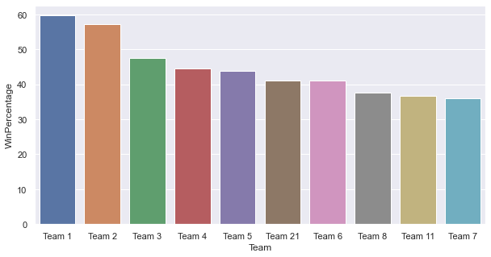

```python
#Best performing teams based on game win percentage
#Win Pecentage = Number of games won/number of games played. Higher the better.
dfs1 = df.sort_values(by = ['WinPercentage'], ascending=False).head(10)
print(dfs1[['Team', 'WinPercentage']])
import seaborn as sns
sns.set(rc={'figure.figsize':(10,5)})
sns.barplot(x='Team',y='WinPercentage', data=dfs1)
```

```
       Team  BasketRatio
1    Team 2     1.894669
0    Team 1     1.893949
2    Team 3     1.370202
3    Team 4     1.267801
4    Team 5     1.251622
20  Team 21     1.130545
5    Team 6     1.091017
7    Team 8     0.999381
8    Team 9     0.942396
10  Team 11     0.937843
```

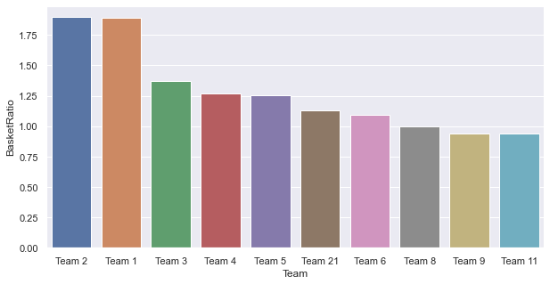

```python
#Best performing teams based on Basket Ratio
#Basket Ratio = Number of baskets scored/number of baskets conceded. Higher the better.
dfs2 = df.sort_values(by = ['BasketRatio'], ascending=False).head(10)
print(dfs2[['Team', 'BasketRatio']])
sns.barplot(x='Team',y='BasketRatio', data=dfs2)
```

```
       Team  ChampionshipTitleScore
0    Team 1                    44.5
1    Team 2                    37.5
2    Team 3                    14.0
4    Team 5                    11.5
3    Team 4                     9.0
7    Team 8                     3.5
10  Team 11                     3.5
5    Team 6                     3.0
9   Team 10                     1.0
20  Team 21                     0.5
```

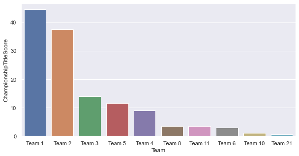

```python
#Best performig teams based on Championship Title Score
#Championship Title Score is a metric created to assess team's performance at winning titles and coming as runner up. Runner up count has been given a weight of 0.5 times the weight of tournament championship count. Higher the better.
dfs3 = df.sort_values(by = ['ChampionshipTitleScore'], ascending=False).head(10)
print(dfs3[['Team', 'ChampionshipTitleScore']])
sns.barplot(x='Team',y='ChampionshipTitleScore', data=dfs3)
```

```
      Team  Score
0   Team 1   4385
1   Team 2   4262
2   Team 3   3442
3   Team 4   3386
4   Team 5   3368
5   Team 6   2819
6   Team 7   2792
7   Team 8   2573
8   Team 9   2109
9  Team 10   1884
```

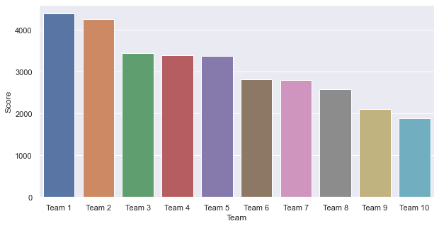

```python
#Best performing teams based on Score
dfs4 = df.sort_values(by = ['Score'], ascending=False).head(10)
print(dfs4[['Team', 'Score']])
sns.barplot(x='Team',y='Score', data=dfs4)
```

```
       Team  WinPercentage
59  Team 60      16.666667
54  Team 55      19.117647
56  Team 57      21.052632
55  Team 56      21.052632
45  Team 46      22.807018
32  Team 33      23.214286
57  Team 58      23.333333
58  Team 59      23.333333
48  Team 49      23.750000
42  Team 43      24.342105
```

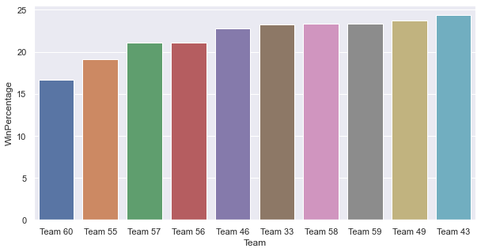

```python
#Worst performing teams based on win percentage
dfs6 = df.sort_values(by = ['WinPercentage'], ascending=True).head(10)
print(dfs6[['Team', 'WinPercentage']])
sns.barplot(x='Team',y='WinPercentage', data=dfs6)
```

```
       Team  BasketRatio
54  Team 55     0.384615
59  Team 60     0.523077
47  Team 48     0.529915
49  Team 50     0.575397
56  Team 57     0.575758
32  Team 33     0.593656
33  Team 34     0.595092
58  Team 59     0.600000
48  Team 49     0.608696
27  Team 28     0.611895
```

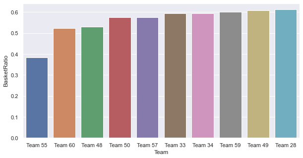

```python
#Worst performing teams based on Basket Ratio
dfs7 = df.sort_values(by = ['BasketRatio'], ascending=True).head(10)
print(dfs7[['Team', 'BasketRatio']])
sns.barplot(x='Team',y='BasketRatio', data=dfs7)
```

```
       Team  Score
59  Team 60     14
58  Team 59     19
57  Team 58     22
56  Team 57     34
55  Team 56     35
54  Team 55     40
53  Team 54     42
52  Team 53     52
51  Team 52     56
50  Team 51     71
```

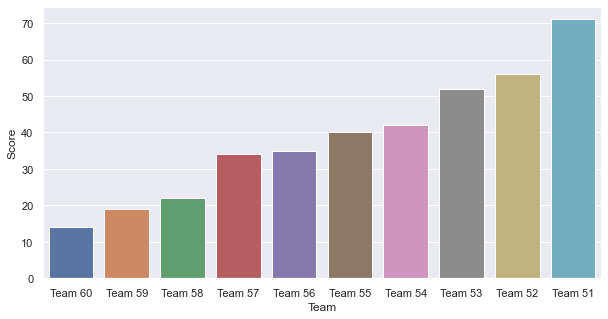

```python
#Worst performing teams based on Score
dfs8 = df.sort_values(by = ['Score'], ascending=True).head(10)
print(dfs8[['Team', 'Score']])
sns.barplot(x='Team',y='Score', data=dfs8)
```

```
       Team  HighestPositionHeld
56  Team 57                   20
48  Team 49                   19
55  Team 56                   17
42  Team 43                   17
47  Team 48                   17
58  Team 59                   16
57  Team 58                   16
54  Team 55                   16
59  Team 60                   15
50  Team 51                   14
```

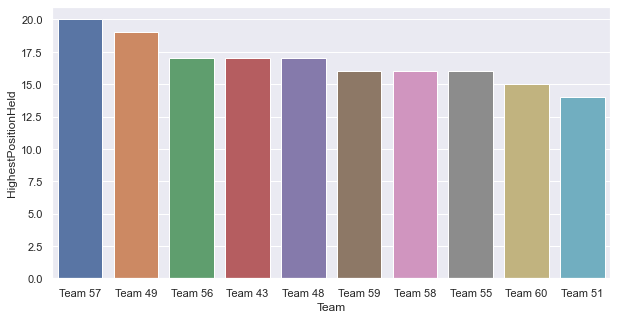

```python
#Worst performing teams based on Highest Position Held
dfs9 = df.sort_values(by = ['HighestPositionHeld'], ascending=False).head(10)
print(dfs9[['Team', 'HighestPositionHeld']])
sns.barplot(x='Team',y='HighestPositionHeld', data=dfs9)
```

```
       Team  BasketScored
0    Team 1          5947
1    Team 2          5900
4    Team 5          4631
2    Team 3          4534
3    Team 4          4398
5    Team 6          3680
6    Team 7          3609
7    Team 8          3228
8    Team 9          2683
11  Team 12          2278
```

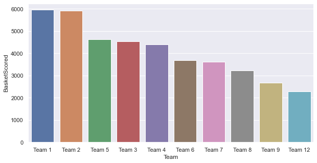

```python
#Teams with Highest Goals Scored
dfs10 = df.sort_values(by = ['BasketScored'], ascending=False).head(10)
print(dfs10[['Team', 'BasketScored']])
sns.barplot(x='Team',y='BasketScored', data=dfs10)
```

```python
#Oldest Team
df.sort_values(by = ['TeamLaunch'], ascending=True).head(15)
```

|  | Team | Tournament | Score | PlayedGames | WonGames | DrawnGames | LostGames | BasketScored | BasketGiven | TournamentChampion | Runner-up | TeamLaunch | HighestPositionHeld | WinPercentage | BasketRatio | ChampionshipTitleScore |
| --- | --- | --- | --- | --- | --- | --- | --- | --- | --- | --- | --- | --- | --- | --- | --- | --- |
| 0 | Team 1 | 86 | 4385 | 2762 | 1647 | 552 | 563 | 5947 | 3140 | 33 | 23 | 1929 | 1 | 59.630702 | 1.893949 | 44.5 |
| 51 | Team 52 | 4 | 56 | 72 | 21 | 14 | 37 | 153 | 184 | 0 | 0 | 1929 | 6 | 29.166667 | 0.831522 | 0.0 |
| 13 | Team 14 | 44 | 1416 | 1428 | 453 | 336 | 639 | 1843 | 2368 | 0 | 1 | 1929 | 2 | 31.722689 | 0.778294 | 0.5 |
| 7 | Team 8 | 70 | 2573 | 2302 | 864 | 577 | 861 | 3228 | 3230 | 2 | 3 | 1929 | 1 | 37.532580 | 0.999381 | 3.5 |
| 6 | Team 7 | 82 | 2792 | 2626 | 948 | 608 | 1070 | 3609 | 3889 | 0 | 0 | 1929 | 3 | 36.100533 | 0.928002 | 0.0 |
| 44 | Team 45 | 7 | 107 | 130 | 43 | 21 | 66 | 227 | 308 | 0 | 0 | 1929 | 3 | 33.076923 | 0.737013 | 0.0 |
| 4 | Team 5 | 86 | 3368 | 2762 | 1209 | 633 | 920 | 4631 | 3700 | 8 | 7 | 1929 | 1 | 43.772629 | 1.251622 | 11.5 |
| 2 | Team 3 | 80 | 3442 | 2614 | 1241 | 598 | 775 | 4534 | 3309 | 10 | 8 | 1929 | 1 | 47.475134 | 1.370202 | 14.0 |
| 1 | Team 2 | 86 | 4262 | 2762 | 1581 | 573 | 608 | 5900 | 3114 | 25 | 25 | 1929 | 1 | 57.241130 | 1.894669 | 37.5 |
| 53 | Team 54 | 3 | 42 | 54 | 18 | 6 | 30 | 97 | 131 | 0 | 0 | 1929 | 8 | 33.333333 | 0.740458 | 0.0 |
| 28 | Team 29 | 12 | 421 | 380 | 125 | 81 | 174 | 458 | 623 | 0 | 0 | 1930-31 | 6 | 32.894737 | 0.735152 | 0.0 |
| 3 | Team 4 | 82 | 3386 | 2664 | 1187 | 616 | 861 | 4398 | 3469 | 6 | 6 | 1931-32 | 1 | 44.557057 | 1.267801 | 9.0 |
| 9 | Team 10 | 51 | 1884 | 1728 | 606 | 440 | 682 | 2159 | 2492 | 1 | 0 | 1932-33 | 1 | 35.069444 | 0.866372 | 1.0 |
| 17 | Team 18 | 38 | 1174 | 1192 | 408 | 292 | 492 | 1642 | 1951 | 0 | 0 | 1933-34 | 3 | 34.228188 | 0.841620 | 0.0 |
| 5 | Team 6 | 73 | 2819 | 2408 | 990 | 531 | 887 | 3680 | 3373 | 1 | 4 | 1934-35 | 1 | 41.112957 | 1.091017 | 3.0 |

```python
#Newest Team
df.sort_values(by = ['TeamLaunch'], ascending=False).head(10)
```

|  | Team | Tournament | Score | PlayedGames | WonGames | DrawnGames | LostGames | BasketScored | BasketGiven | TournamentChampion | Runner-up | TeamLaunch | HighestPositionHeld | WinPercentage | BasketRatio | ChampionshipTitleScore |
| --- | --- | --- | --- | --- | --- | --- | --- | --- | --- | --- | --- | --- | --- | --- | --- | --- |
| 55 | Team 56 | 1 | 35 | 38 | 8 | 11 | 19 | 36 | 55 | 0 | 0 | 2016-17 | 17 | 21.052632 | 0.654545 | 0.0 |
| 43 | Team 44 | 3 | 132 | 114 | 35 | 27 | 52 | 139 | 167 | 0 | 0 | 2014-15 | 10 | 30.701754 | 0.832335 | 0.0 |
| 56 | Team 57 | 1 | 34 | 38 | 8 | 10 | 20 | 38 | 66 | 0 | 0 | 2009-10 | 20 | 21.052632 | 0.575758 | 0.0 |
| 36 | Team 37 | 6 | 242 | 228 | 62 | 56 | 110 | 244 | 366 | 0 | 0 | 2007-08 | 8 | 27.192982 | 0.666667 | 0.0 |
| 24 | Team 25 | 12 | 553 | 456 | 147 | 112 | 197 | 520 | 633 | 0 | 0 | 2004-05 | 6 | 32.236842 | 0.821485 | 0.0 |
| 42 | Team 43 | 4 | 148 | 152 | 37 | 37 | 78 | 155 | 253 | 0 | 0 | 1999-00 | 17 | 24.342105 | 0.612648 | 0.0 |
| 20 | Team 21 | 17 | 970 | 646 | 266 | 172 | 208 | 892 | 789 | 0 | 1 | 1998-99 | 2 | 41.176471 | 1.130545 | 0.5 |
| 47 | Team 48 | 2 | 83 | 80 | 20 | 23 | 37 | 62 | 117 | 0 | 0 | 1996-97 | 17 | 25.000000 | 0.529915 | 0.0 |
| 48 | Team 49 | 2 | 81 | 80 | 19 | 24 | 37 | 70 | 115 | 0 | 0 | 1995-96 | 19 | 23.750000 | 0.608696 | 0.0 |
| 38 | Team 39 | 4 | 190 | 160 | 52 | 45 | 63 | 199 | 241 | 0 | 0 | 1994-95 | 10 | 32.500000 | 0.825726 | 0.0 |

```
False    51
True      9
Name: HighestPositionHeld, dtype: int64
```

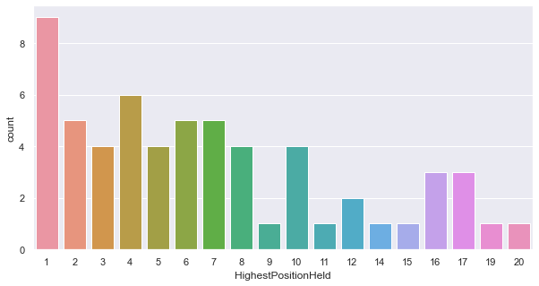

```python
#Count of Highest Positions Held
sns.countplot('HighestPositionHeld', data=df)
(df['HighestPositionHeld']==1).value_counts()
```

# Performance Report

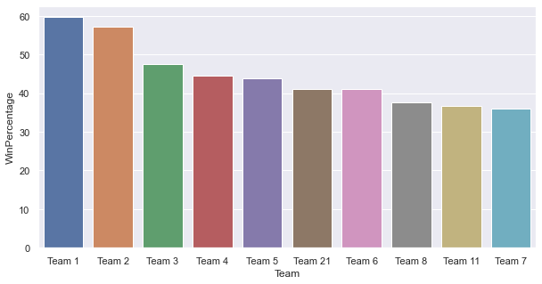

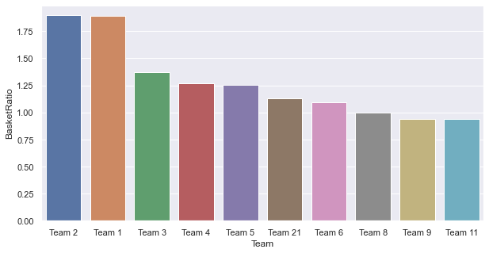

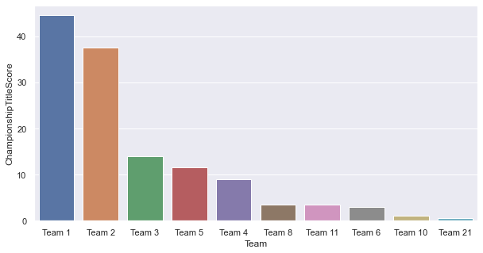

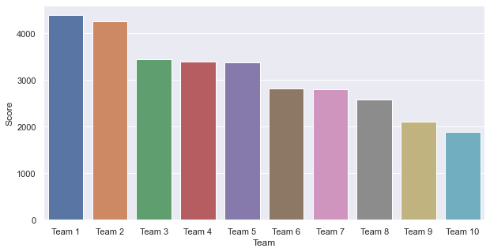

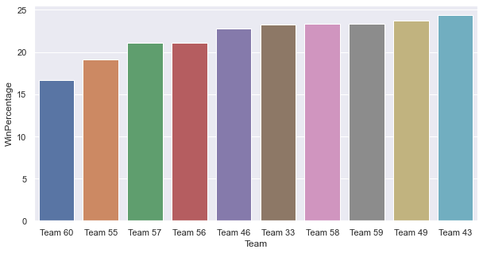

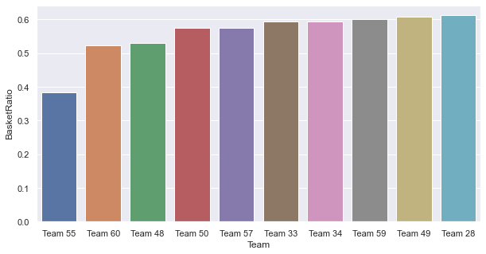

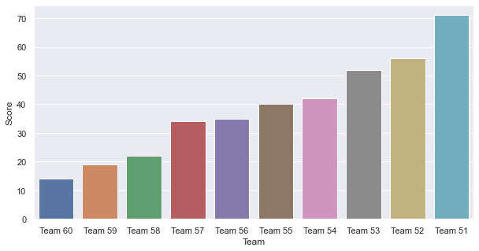

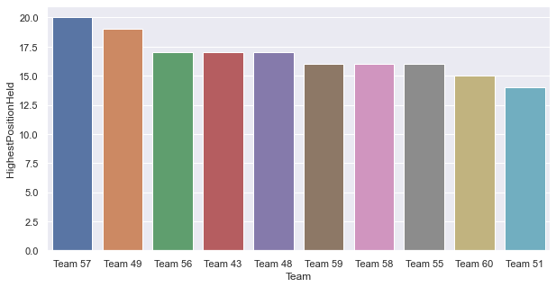

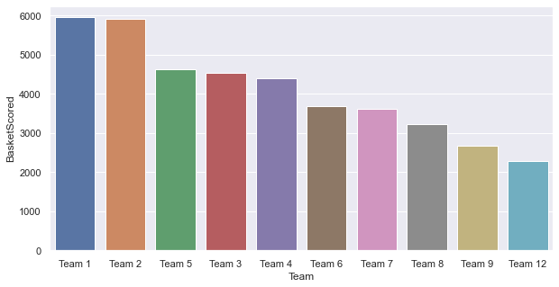

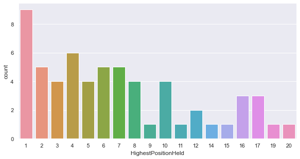

```python
# Performance Charts
import matplotlib.pyplot as plt
sns.barplot(x='Team',y='WinPercentage', data=dfs1)
plt.show()
sns.barplot(x='Team',y='BasketRatio', data=dfs2)
plt.show()
sns.barplot(x='Team',y='ChampionshipTitleScore', data=dfs3)
plt.show()
sns.barplot(x='Team',y='Score', data=dfs4)
plt.show()
sns.barplot(x='Team',y='WinPercentage', data=dfs6)
plt.show()
sns.barplot(x='Team',y='BasketRatio', data=dfs7)
plt.show()
sns.barplot(x='Team',y='Score', data=dfs8)
plt.show()
sns.barplot(x='Team',y='HighestPositionHeld', data=dfs9)
plt.show()
sns.barplot(x='Team',y='BasketScored', data=dfs10)
plt.show()
sns.countplot('HighestPositionHeld', data=df)
plt.show()
```

</hr

### Task 3. Please include any improvements or suggestions to the association management on quality, quantity, variety, velocity, veracity etc. on the data points collected by the association to perform a better data analysis in future

- #### More kinds of data on each team like 'Home Games Won' & 'Away Games Won' if gathered would help in assessing the team performance in additional perspectives
- #### The formatting of data gathered in the field TeamLaunch could have been more consistent. Different symbols like ~,-,_ were used to denote year interval.
- #### The quality or accuracy of data gathered in the field TeamLaunch could have been better. The exact year in which the team was launched could have been captured instead of year intervals (ex:2016-17).
- #### The presence of invalid/missing data for Team61 in the dataset makes the veracity of the dataset questionable. Team 61 is listed in the dataset with Tournaments Played = 1 and Highest Position Held = 9, but all other fields including Games Won and Goals Scored are blank.